[figure not shown]

基因组注释分析报告

# 1 项目概况

## 1.1 项目信息

| 合同编号 | BN210701ZJ01S20N1 |
| --- | --- |
| 合同名称 | 1个植物全基因组图谱开发（测序及分析）胡柚 |
| 样品名称 | Citrus changshan-huyou |
| 目标物种 | Citrus changshan-huyou |
| 联系邮箱 | pm@benagen.com |
| 撰写时间 | 2022-01-17 |

## 1.2 合同关键指标及完成情况

| 合同指标 | 完成情况 |
| --- | --- |
| BUSCO>90% | BUSCO=98.6% |
| 结构注释 | 完成 |
| 功能注释 | 完成 |

# 2 基因组注释

基因组注释包括：1）重复序列注释；2）基因注释（基因结构预测和基因功能注释）；3）非编码RNA注释。生信注释流程见下图：

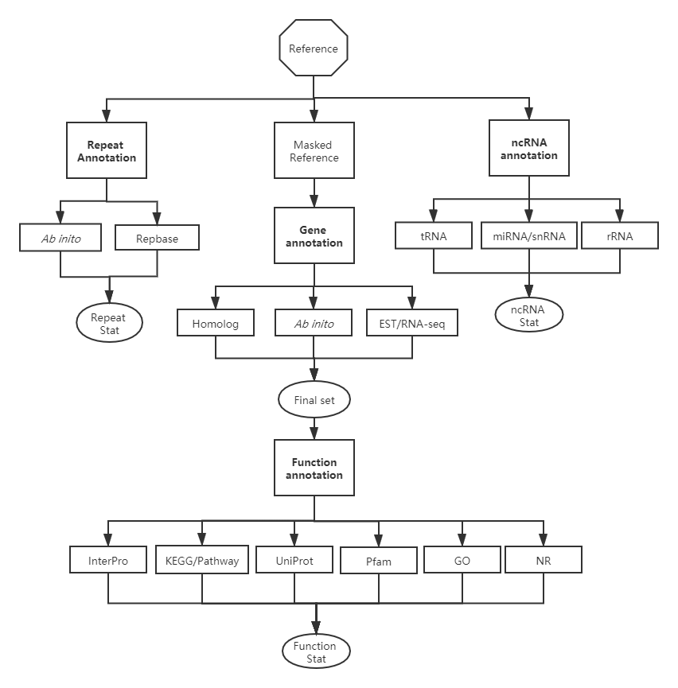

##### 图 1 基因组注释分析流程图

## 2.1 重复序列注释

重复序列可分为散在重复序列和串联重复序列。散在重复序列又称转座子元件，包括 4 种： LTR、LINE、SINE 和 DNA 转座子。

首先使用软件 RepeatMasker （version：open-4.0.9） (Smith et al. 2013) 基于 RepBase 库（http://www.girinst.org/repbase） 进行重复注释；继而使用软件 RepeatModeler（version：open-1.0.11） (Smit et al. 2015) 基于自身序列特征进行denovo预测建库，同样使用软件 RepeatMasker（version：open-4.0.9） (Smith et al. 2013) 比对并预测重复序列；最后，将所有重复预测结果合并去冗余，得到最终基因组重复序列集 Combined TEs。

表 1 重复序列基本统计

| Type | TE protiens Length (Bp) | TE protiens % in genome | De novo + repbase Length (Bp) | De novo + repbase % in genome | Combined TEs Length (Bp) | Combined TEs % in genome |
| --- | --- | --- | --- | --- | --- | --- |
| DNA | 2,486,763 | 0.78 | 22,391,268 | 6.98 | 22,727,908 | 7.09 |
| LINE | 2,223,227 | 0.69 | 5,557,928 | 1.73 | 5,674,454 | 1.77 |
| SINE | 0 | 0.00 | 6,638 | 0.00 | 6,638 | 0.00 |
| LTR | 36,994,711 | 11.53 | 67,714,075 | 21.11 | 76,019,984 | 23.70 |
| LTR-Gypsy | 16,081,031 | 5.01 | 34,686,269 | 10.81 | 37,286,876 | 11.62 |
| LTR-Copia | 14,731,973 | 4.59 | 27,571,434 | 8.60 | 29,534,807 | 9.21 |
| Satellite | 0 | 0.00 | 557,731 | 0.17 | 557,731 | 0.17 |
| Simple_repeat | 0 | 0.00 | 202,355 | 0.06 | 202,355 | 0.06 |
| Other | 0 | 0.00 | 2,683 | 0.00 | 2,683 | 0.00 |
| Unknown | 11,781 | 0.00 | 46,040,221 | 14.35 | 46,051,729 | 14.36 |
| Total | 41,712,670 | 13.00 | 139,803,008 | 43.59 | 152,561,276 | 47.56 |

注：1.DNA：DNA 转座子。包括 MITEs , Helitrons 等；2.LINE（long interspersed nuclear element）：长散在重复序列（非 LTR）。Non-LTR 之一，反转录转座子的一种，包括 L1，R2，Jockey 等；3.SINE（short iterspersed element）：短散在重复序列。Non-LTR之一，反转录转座子的一种，包括 V-SINE，AmnSINE，CORE-SINE 等；4.LTR（long terminal repeat）：长末端重复序列。反转录转座子的一种，主要包括 Gypsy，Copia 两种类型。不编码蛋白质，但含有启动子，增强子等调控元件；5.Satellite：卫星 DNA。是一类高度重复序列，GC 表现为极高或极低，一般在着丝粒和端粒附近。6.Simple_repeat:简单串联重复序列（即 SSR)；与 Satellite 类似，一般不做具体区分；广泛随机地分布于真核生物基因组中；7.Other:未分类的 DNA 转座子，如 Mirage，P-element，Transib 等；8.Unknown：可以被标记但尚未分类的重复序列。

## 2.2 基因结构预测

通过基因结构预测，能够获得基因组详细的基因分布和结构信息，是功能注释和进化分析工作的基础。基因结构预测包括基因位点的预测、开放性阅读框架（ORF）、翻译起始位点和终止位点、内含子和外显子区域、启动子、可变剪切位点以及蛋白质编码序列的预测等。

本研究基因结构预测使用同源预测、从头预测、转录本预测相结合的方法。其中，homolog 同源预测（至少选两到三个近源物种：具体物种选用见下表 Species 列；软件：Exonerate（version：v2.4.0） (Slater and Birney 2005) ）、de novo 从头预测（软件：Augustus（version：3.3.2） (Stanke et al. 2008) 、Genscan（version：1.0） (Salzberg et al. 1998) 、GlimmerHMM（version：3.0.4） (Delcher et al. 2007) 等）、RNA-seq 数据通过 stringtie（version：2.1.4） (Kovaka et al. 2019) 重构得到的转录本，TransDecoder（version：v5.1.0）预测编码框。使用 MAKER（version：2.31.10） (Holt and Yandell 2011) 软件，将各种方法预测得到的基因集进行整合。通过过滤，形成一个非冗余的、更加完整的基因集。并对此进行评价。

表 2 所有证据集基本统计

| Method | Software | Species | Gene number | Average gene length (bp) | Average CDS length (bp) | Average exon per gene | Average exon length (bp) | Average intron length (bp) |
| --- | --- | --- | --- | --- | --- | --- | --- | --- |
| Ab initio | GlimmmerHMM |  | 51,569.0 | 5,616.83 | 1,007.18 | 3.80 | 265.20 | 1,647.61 |
| Ab initio | AUGUSTUS |  | 38,011.0 | 2,532.57 | 1,136.97 | 4.61 | 246.76 | 386.84 |
| Homology-based | Exonerate | Citrus_clementina | 47,394.0 | 14,276.54 | 892.71 | 3.54 | 252.39 | 5,275.39 |
| Homology-based | Exonerate | Citrus_sinensis | 72,898.0 | 9,400.93 | 615.7 | 2.82 | 218.60 | 4,836.28 |
| Homology-based | Exonerate | Citrus_maxima | 54,859.0 | 12,402.99 | 790.74 | 3.36 | 235.42 | 4,922.89 |
| Homology-based | Exonerate | Citrus_reticulata | 107,137.0 | 8,847.18 | 579.33 | 2.85 | 203.30 | 4,470.18 |
| Homology-based | Exonerate | Citrus_medica | 96,012.0 | 8,376.04 | 626.33 | 2.94 | 213.33 | 4,003.06 |
| RNAseq | TransDecoder |  | 13,960.0 | 4,941.07 | 1,338.19 | 6.46 | 316.52 | 529.74 |
| Integration | Maker |  | 32,758.0 | 4,080.25 | 1,131.58 | 4.76 | 287.72 | 720.82 |
| Final set | Anno-self |  | 34,785.0 | 3,550.21 | 1,081.73 | 4.49 | 299.79 | 627.86 |

注：Method 对应不同的证据类型；Software 为该证据使用的软件； Species 为同源注释使用的近缘物种拉丁名；Gene number 为该证据注释到的本物种基因数；Average gene length 为注释到基因的（下同）平均的 mRNA 长度；Average CDS length 为平均的 CDS 长度；Average exon per gene 为每基因包含的平均外显子数；Average exon length 为平均的外显子长度；Average intron length 为平均的内含子长度。

表 3 编码基因预测结果统计

| Item | Number |
| --- | --- |
| the total number of gene | 34,785 |
| the average of mRNA_length (bp) | 3,550.21 |
| the average cds_length of per gene (bp) | 1,081.73 |
| the average exon_number of per gene | 4.49 |
| the average of exon_length (bp) | 299.79 |
| the average of intron_length (bp) | 627.86 |
| the total number of exon | 156,345 |
| the total number of intron | 121,560 |
| the total intron length (bp) | 76,322,681 |

注：the total number of gene 为总基因数；the average of mRNA_length 为平均的 mRNA 长度；the average of CDS_length 为平均的 CDS 长度；the average of exon_number 为每基因包含的平均外显子数；the average of exon_length 为平均的外显子长度；the average of intron_length 为平均的内含子长度；the total number of exon 为总外显子数；the total number of intron 为总内含子数；the total intron length 为总的内含子长度。

因为近缘物种之间的基因长度频数分布往往具有相似的特征。故而所选近缘物种和本物种的长度分布情况，能够在整体上直观地反映注释结果的质量好坏。按照 10bp 一个窗口绘制各个物种基因长度、CDS 长度、内含子长度、外显子长度的分布图，如下：

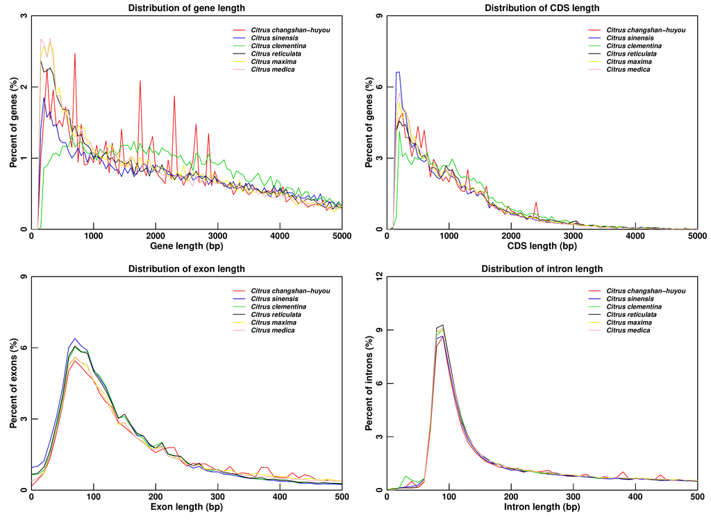

## 2.3 BUSCO评价

使用 BUSCO 软件（version：5.2.2） (Manni et al. 2021) 来评估基因组注释的完整性，BUSCO 评价一般大于 90%，认为基因组注释较好。

表 4 基因集BUSCO评价结果（busco_lineage：embryophyta_odb10）

|  | Assembly Proteins | Assembly Percentage (%) | Annotation Proteins | Annotation Percentage (%) |
| --- | --- | --- | --- | --- |
| Complete BUSCOs | 1,599 | 99.1 | 1,592 | 98.6 |
| Complete Single-Copy BUSCOs | 1,586 | 98.3 | 1,584 | 98.1 |
| Complete Duplicated BUSCOs | 13 | 0.8 | 8 | 0.5 |
| Fragmented BUSCOs | 3 | 0.2 | 3 | 0.2 |
| Missing BUSCOs | 12 | 0.7 | 19 | 1.2 |
| Total BUSCO groups searched | 1,614 | 100.0 | 1,614 | 100.0 |

注：Complete BUSCOs 为检测到完整的 BUSCO，完整性定义为检测到的基因长度在 BUSCO 同源组中平均长度 95% 置信区间内；Complete and single BUSCOs 为检测到完整的 BUSCO，且是单拷贝的；Complete and duplicated BUSCOs 为检测到完整的 BUSCO， 但出现多拷贝情况；Fragmented BUSCOs 为片段化的 BUSCO，即检测到不完整的 BUSCO；Missing BUSCOs 为缺失的 BUSCO，即未检测到的 BUSCO 同源组；Total BUSCO group searched 为使用的数据库中 BUSCO 个数。

## 2.4 基因功能注释

基因的功能注释是指根据已有数据库对基因功能和所参与的代谢途径进行标注，包括 Motif、结构域、蛋白质功能及所在的代谢通路等信息的预测。

基因功能注释主要有如下两种方法：

（1）序列相似性搜索：将基因集中基因编码的蛋白序列与现有蛋白质数据库 Uniprot (Apweiler et al. 2004) 、NR (Deng et al. 2006) 以及代谢通路数据库 KEGG (Kanehisa and Goto 2000) 进行 diamond blastp（version ：2.0.11.149；参数：–evalue 1e-5） (Buchfink et al. 2015) 比对，获得序列的功能信息，以及蛋白可能参与的代谢通路信息。其中 KEGG (Kanehisa and Goto 2000) 注释使用 KOBAS（version: 3.0） (Xie et al. 2011) 关联到 KEGG ORTHOLOGY 以及 PATHWAY (Kanehisa and Goto 2000) 。Uniprot (Apweiler et al. 2004) 数据库记录了每个蛋白质家族与 Gene Ontology (Ashburner et al. 2000) 中的功能节点的对应关系，通过此系统预测基因编码的蛋白序列所执行的生物学功能。

（2）Motif 相似性搜索，利用 InterProScan（version：5.52-86.0） (Blum et al. 2021) 对二级数据库 InterPro 子数据中的 CDD、Gene3D、Hamap、Panther、Pfam、Phobius、Pirsf、Pirsr、Prints、Prosite、Sfld、Smart、Superfamily、Tigrfam 以及 Tmhmm 数据库进行比对，获得蛋白质的保守序列、motif 和结构域等。此外，还使用 hmmscan（版本：3.3.2；参数：e-value 0.01）进行结构域预测，获得蛋白质的保守序列、motif 和结构域等。Pfam (Finn et al. 2014) 数据库是一个蛋白质家族大集合，依赖于多序列比对和隐马尔可夫模型。

表 5 编码基因功能注释结果统计

| Item | Count | Percentage |
| --- | --- | --- |
| All | 34,785 | 100% |
| Annotation | 32,031 | 92.08% |
| Uniprot | 29,466 | 84.71% |
| Pfam | 21,333 | 61.33% |
| GO | 21,414 | 61.56% |
| KEGG | 10,675 | 30.69% |
| Pathway | 5,567 | 16.00% |
| Interproscan | 30,028 | 86.32% |
| NR | 29,868 | 85.86% |

注：All 为所有基因的数量；Annotation 为至少有一种注释的基因；Uniprot 为注释到 Uniprot 数据库的基因；Pfam 为注释到 Pfam 数据库的基因；GO 为注释到 GO 数据库的基因；KEGG 为注释到 KEGG 数据库的基因； Pathway 为注释到 KEGG Pathway 数据库的基因；Interproscan 为注释到 Interproscan 数据库的基因；NR 为注释到 NR 数据库的基因。

## 2.5 非编码 RNA 注释

非编码 RNA ，指的是不被翻译成蛋白质的 RNA，这些RNA都具有重要的生物学功能。其中 tRNA 、rRNA 直接参与蛋白质的合成。

根据tRNA的结构特征，利用 tRNAscan-SE（version：1.23） (Chan et al. 2021) 来寻找基因组中的 tRNA 序列；使用 rRNA 数据库进行 rRNA 预测；利用 INFERNAL（version：1.1.2） (Nawrocki and Eddy 2013) 基于 Rfam 数据库来寻找基因组中的 ncRNA 序列，如 snRNA，miRNA 等。

表 6 非编码RNA注释结果统计

| Type |  | Copy | Average length(bp) | Total length(bp) | % of genome |
| --- | --- | --- | --- | --- | --- |
| miRNA |  | 163 | 127 | 20,646 | 0.006437 |
| tRNA |  | 709 | 75 | 53,002 | 0.016524 |
| rRNA | rRNA | 5,945 | 573 | 3,404,011 | 1.061268 |
|  | 18S | 1,517 | 1712 | 2,596,372 | 0.809470 |
|  | 28S | 2,854 | 199 | 568,094 | 0.177115 |
|  | 5.8S | 1,426 | 156 | 222,080 | 0.069238 |
|  | 5S | 148 | 118 | 17,465 | 0.005445 |
| snRNA | snRNA | 1,545 | 108 | 167,320 | 0.052165 |
|  | CD-box | 1,426 | 106 | 151,179 | 0.047133 |
|  | HACA-box | 39 | 126 | 4,907 | 0.001530 |
|  | splicing | 80 | 140 | 11,234 | 0.003502 |
|  | scaRNA | 0 | 0 | 0 | 0.000000 |

注：miRNA 为小的调控 RNA；tRNA 为转运 RNA；rRNA 为核糖体 RNA；snRNA 为核仁小 RNA。

# 3 软件及数据库列表

表 7 软件及数据库汇总表

| 软件/数据库 | 版本 | 分析 | 网址 |
| --- | --- | --- | --- |
| BLAST+ | 2.7.1 | 比对 | https://github.com/enormandeau/ncbi_blast_tutorial |
| RepeatModeler | open-1.0.11 | 构建重复序列模型 | https://github.com/Dfam-consortium/RepeatModeler |
| RepeatMasker | open-4.0.9 | 重复序列鉴定与分类 | https://github.com/rmhubley/RepeatMasker |
| RepBaseRepBase | 2019 | 重复序列库 | http://www.girinst.org/repbase |
| Diamond | 2.0.11.149 | 同源比对 | https://github.com/bbuchfink/diamond |
| Exonerate | 2.4.0 | 同源预测 | https://github.com/nathanweeks/exonerate |
| Augustus | 3.3.2 | denovo预测 | http://augustus.gobics.de/ |
| Genscan | 1.0 | denovo预测 | http://genome.ucsc.edu/cgi-bin/hgTrackUi?g=genscan |
| GlimmerHMM | 3.0.4 | denovo预测 | http://ccb.jhu.edu/software/glimmer/index.shtml |
| hisat2 | 2.1.0 | 转录组比对 | http://daehwankimlab.github.io/hisat2 |
| samtools | 0.1.19 | sam处理 | https://github.com/samtools/samtools |
| Stringtie | 2.1.4 | 转录本预测 | http://ccb.jhu.edu/software/stringtie |
| TransDecoder | v5.1.0 | 开放阅读框预测 | https://github.com/TransDecoder/TransDecoder |
| Maker | 2.31.10 | 证据整合 | http://www.yandell-lab.org/index.html |
| BUSCO | 5.2.2 | 完整性评估 | https://busco.ezlab.org/ |
| INFERNAL | 1.1.2 | ncRNA注释 | https://github.com/EddyRivasLab/infernal |
| tRNAscan-SE | 1.23 | tRNA注释 | http://trna.ucsc.edu/tRNAscan-SE |
| KOBAS | 3.0 | kegg注释 | https://github.com/xmao/kobas |
| InterProScan | 5.52-86.0 | InterProScan注释 | https://github.com/ebi-pf-team/interproscan |
| Uniprot | 202011 | Uniprot功能注释 | https://www.uniprot.org/ |
| hmmscan | 3.3.2 | 功能注释 | http://hmmer.org/ |
| Pfam | 202011 | 结构域注释 | https://pfam.xfam.org/ |
| GO | 202011 | GO功能注释 | http://geneontology.org/ |
| NR | 202011 | NR注释 | https://ftp.ncbi.nlm.nih.gov |

# 4 常见问题说明

Q1：结果文件都是什么？

A：结果目录中有 Structure_Anno_Readme.txt 和 Function_Anno_Readme.txt 说明，详细介绍了每个文件所代表的内容。

Q2：.xls 文件用什么软件打开？

A: 可使用 Microsoft Excel 软件，也可以使用 Sublime 等 TXT 文本查看器打开。

# 5 联系我们

[figure not shown]

```
客 服 电 话：027-62435310
客 服 邮 箱：service@benagen.com
公 司 网 站：www.benagen.com
公 司 地 址：武汉东湖新技术开发区高新大道888号高农生物园总部B区12C栋
```

# 参考文献

Apweiler, R., Bairoch, A., Wu, C. H., Barker, W. C., Boeckmann, B., Ferro, S., Gasteiger, E., Huang, H., Lopez, R., Magrane, M., and others (2004), “UniProt: The universal protein knowledgebase,” *Nucleic acids research*, Oxford University Press, 32, D115–D119.

Ashburner, M., Ball, C. A., Blake, J. A., Botstein, D., Butler, H., Cherry, J. M., Davis, A. P., Dolinski, K., Dwight, S. S., Eppig, J. T., and others (2000), “Gene ontology: Tool for the unification of biology,” *Nature genetics*, Nature Publishing Group, 25, 25–29.

Blum, M., Chang, H.-Y., Chuguransky, S., Grego, T., Kandasaamy, S., Mitchell, A., Nuka, G., Paysan-Lafosse, T., Qureshi, M., Raj, S., and others (2021), “The InterPro protein families and domains database: 20 years on,” *Nucleic acids research*, Oxford University Press, 49, D344–D354.

Buchfink, B., Xie, C., and Huson, D. H. (2015), “Fast and sensitive protein alignment using DIAMOND,” *Nature methods*, Nature Publishing Group, 12, 59–60.

Chan, P. P., Lin, B. Y., Mak, A. J., and Lowe, T. M. (2021), “tRNAscan-SE 2.0: Improved detection and functional classification of transfer RNA genes,” *BioRxiv*, Cold Spring Harbor Laboratory, 614032.

Delcher, A. L., Bratke, K. A., Powers, E. C., and Salzberg, S. L. (2007), “Identifying bacterial genes and endosymbiont DNA with glimmer,” *Bioinformatics*, Oxford University Press, 23, 673–679.

Deng, Y., Li, J., Wu, S., Zhu, Y., Chen, Y., He, F., and others (2006), “Integrated nr database in protein annotation system and its localization,” *Comput Eng*, 32, 71–2.

Finn, R. D., Bateman, A., Clements, J., Coggill, P., Eberhardt, R. Y., Eddy, S. R., Heger, A., Hetherington, K., Holm, L., Mistry, J., and others (2014), “Pfam: The protein families database,” *Nucleic acids research*, Oxford University Press, 42, D222–D230.

Holt, C., and Yandell, M. (2011), “MAKER2: An annotation pipeline and genome-database management tool for second-generation genome projects,” *BMC bioinformatics*, BioMed Central, 12, 1–14.

Kanehisa, M., and Goto, S. (2000), “KEGG: Kyoto encyclopedia of genes and genomes,” *Nucleic acids research*, Oxford University Press, 28, 27–30.

Kovaka, S., Zimin, A. V., Pertea, G. M., Razaghi, R., Salzberg, S. L., and Pertea, M. (2019), “Transcriptome assembly from long-read RNA-seq alignments with StringTie2,” *Genome biology*, BioMed Central, 20, 1–13.

Manni, M., Berkeley, M. R., Seppey, M., Simao, F. A., and Zdobnov, E. M. (2021), “BUSCO update: Novel and streamlined workflows along with broader and deeper phylogenetic coverage for scoring of eukaryotic, prokaryotic, and viral genomes,” *arXiv preprint arXiv:2106.11799*.

Nawrocki, E. P., and Eddy, S. R. (2013), “Infernal 1.1: 100-fold faster RNA homology searches,” *Bioinformatics*, Oxford University Press, 29, 2933–2935.

Salzberg, S., Searls, D., and Kasif, S. (1998), “Modeling dependencies in pre-mRNA splicing signals,” *Computational methods in molecular biology*, Elsevier, 129.

Slater, G. S. C., and Birney, E. (2005), “Automated generation of heuristics for biological sequence comparison,” *BMC bioinformatics*, Springer, 6, 1–11.

Smit, A., Hubley, R., and Green, P. (2015), “RepeatModeler open-1.0 (2008–2015),” *Seattle, USA: Institute for Systems Biology. Available from: httpwww. repeatmasker. org, Last Accessed May*, 1, 2018.

Smith, A., Hubley, R., and Green, P. (2013), “RepeatMasker open-4.0,” *RepeatMasker Open-4.0*.

Stanke, M., Diekhans, M., Baertsch, R., and Haussler, D. (2008), “Using native and syntenically mapped cDNA alignments to improve de novo gene finding,” *Bioinformatics*, Oxford University Press, 24, 637–644.

Xie, C., Mao, X., Huang, J., Ding, Y., Wu, J., Dong, S., Kong, L., Gao, G., Li, C.-Y., and Wei, L. (2011), “KOBAS 2.0: A web server for annotation and identification of enriched pathways and diseases,” *Nucleic acids research*, Oxford University Press, 39, W316–W322.